# Presentation of Netflix Title Analysis

May 8, 2025

Hudson Colletti

## Overview of Data

- Analysis of Netflix Movies & TV Shows
- Data from [TidyTuesday (2021-04-20)](https://github.com/rfordatascience/tidytuesday)
- Focus on trends in U.S. content, title length, and naming conventions
- Data originally collected by [Shivam Bansal on Kaggle](https://www.kaggle.com/datasets/shivamb/netflix-shows/data)

## Visualization 1 - Netflix Content Trends Over Time in the United States

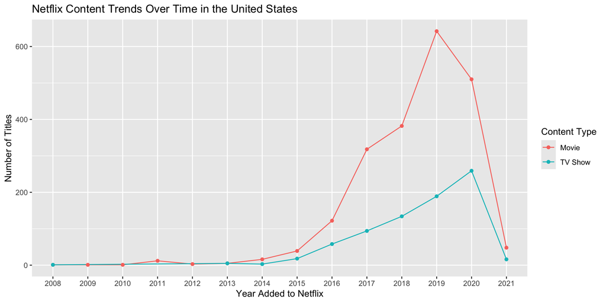

## Visualization 1 Analysis

From 2015 onward, there is a steep increase in content added to Netflix in the U.S. Movies drive most of the growth, but TV Shows also rise sharply.

- The sudden drop in 2021 likely reflects:
  - COVID-19 production slowdowns
  - Partial year data
  - Internal Netflix policy shifts

## Visualization 2 - Average Netflix Title Length Over Time

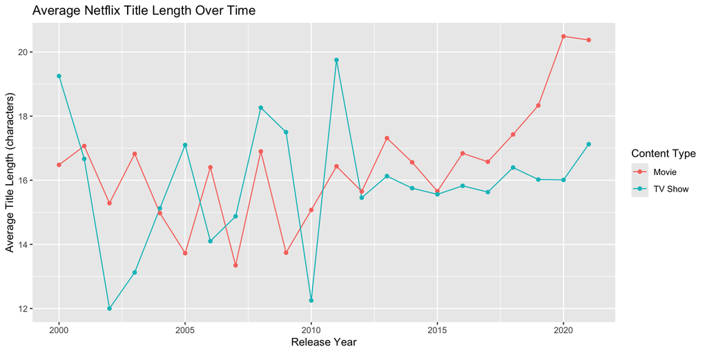

## Visualization 2 Analysis

- Movie title lengths have fluctuated over time, with consistently longer titles after 2015.
- TV show title lengths fluctuated from 2000-2012
  - Since 2012, TV titles have stabilized between 15–17 characters
- Movie titles are now typically longer than TV Shows

## Visualization 3 - Netflix Titles Starting with ‘A’ or ‘An’ Over Time

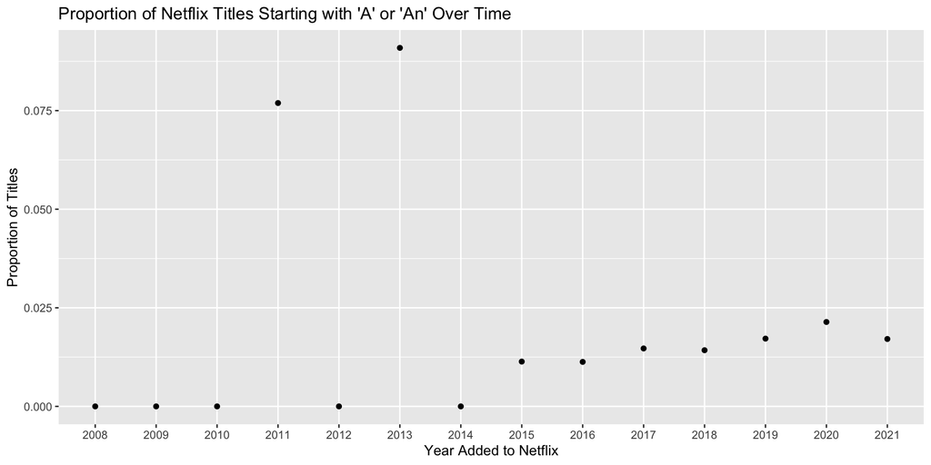

## Visualization 3 Analysis

- Between 2008-2014 the proportion of titles beginning with ‘A’/‘An’ was extremely low. 2011 and 2013 are outlier years possibly explained by:
  - Low total title counts
  - Certain acquisitions that skewed overall
- The proportion of titles beginning with these articles increased sharply from 2015 on
  - This growth may reflect a gaming of alphabetization in recommendation interfaces.
- These proportions stabilize between 1.5-2.5% of all titles.

## Summarized Conclusions

- Netflix’s title trends reflect strategic business choices:
  - Rapid content expansion
  - Title naming decisions
- These patterns provide insight into how data can shift business models in the streaming industry
- As the overall number of titles released on Netflix grew, the proportion of titles with ‘A’/‘An’ increased as well.

# Thanks for Watching

Any Questions?